# Studio del genere Action e di alcune sue varianti

## Introduzione

Come maggior parte di noi ragazzi, anche io sono fan della tecnologia e dei videogiochi; pertanto ho voluto creare questo progetto per fare una analisi sui miei generi preferiti cercando di estrapolare informazioni con lo scopo di ottenere una visione generale su di essi.

- Quali sono i generi da me più giocati
- Le maggiori case di sviluppo
- Confronto critica - giocatori
- Analisi sull’andamento di pubblicazione
- Analisi delle piattaforme
- Conclusioni

## Dataset

Per fare ciò mi sono servito di un dataset ottenuto su Kaggle:

- Dati sulla critica dei videogames del portale MeatCritic: [VGList](https://www.kaggle.com/datasets/brunovr/metacritic-videogames-data)

Esso contiene dati di circa 18.000 giochi: uscita, sviluppatori, generi, voti di critica e giocatori; in più ho usato il dataset dei miei mideogiochi creato da me che poi ho unito a VGList per ottenere in automatico i generi dei giochi. Il dataset è stato opportunatamente sistemato, per eliminare dati superflui che non servivano alla mia analisi, o per addattare il formato dei valori di alcune variabili. In particolare:

- La data: ho mantenuto solo l’anno di pubblicazione del videogioco
- Generi e sviluppatori: li ho separati in più colonne per avere una visione più ampia su di essi

## Quali generi analizzo?

Ho deciso di ricavare dalla lista dei videogiochi da me giocati i 3 generi di videogames da me più apprezzati, basandomi sulla quantità di giochi:

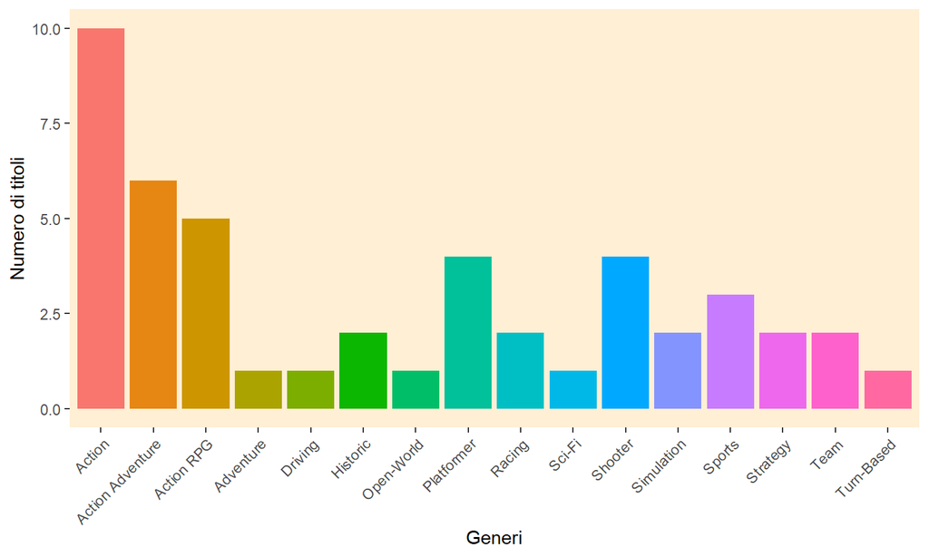

- *Actio*n: 10 titoli
- *Action-Adventure*: 6 titoli
- *Action-RPG*: 5 titoli

## Le maggiori case di sviluppo

Quali sono le case di sviluppo che hanno pubblicato più giochi del genere Action, Action-Adventure e Action-RPG??

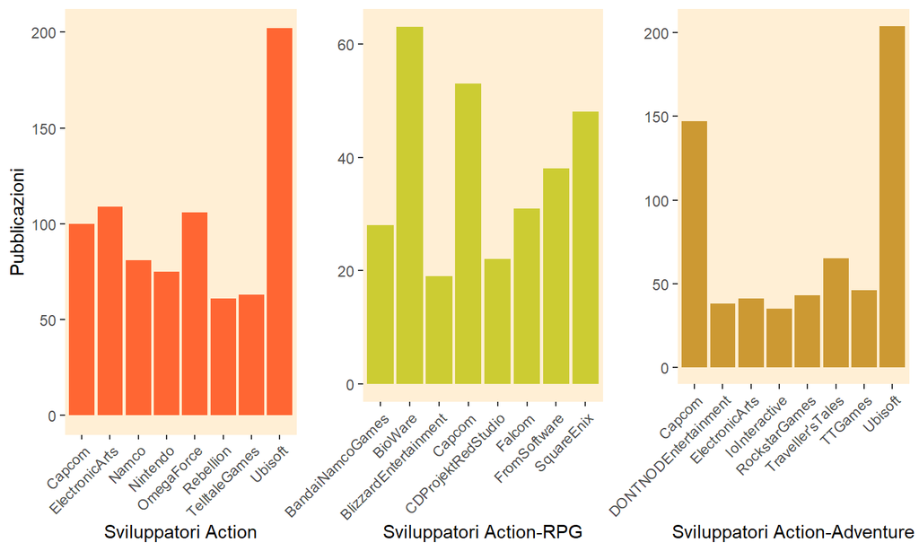

- Maggiori produttori di *Action*: Ubisoft, ElectronicArts (EA), Omegaforce
- Maggiori produttori di *Action-RPG*: BioWare, Capcom, SquareEnix
- Maggiori produttori di *Action-Adventure*: Ubisoft, Capcom, Traveller’s Tales

## Confronto Critica - Giocatori

## Genere Action

Come sono valutate le case di produzione dalla critica e dai giocatori?

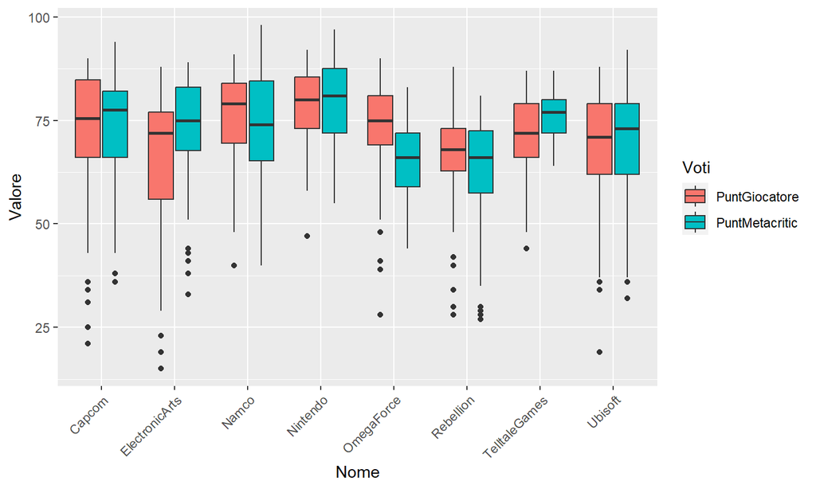

La critica è leggermente più genereosa nelle valutazioni, fanno eccezione in particolare la OmegaForce e la Namco.

## Genere Action-RPG

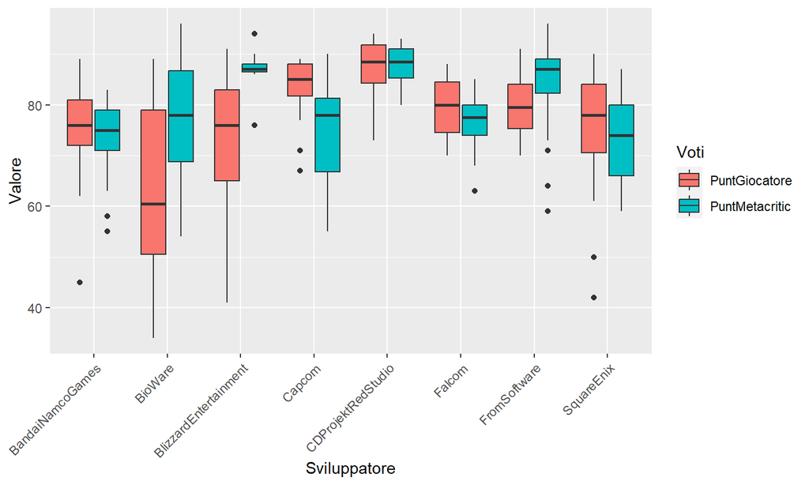

In questo genere si ha una estremizzazione, in termini di giudizio, tra critica e giocatori.

## Genere Action-Adventure

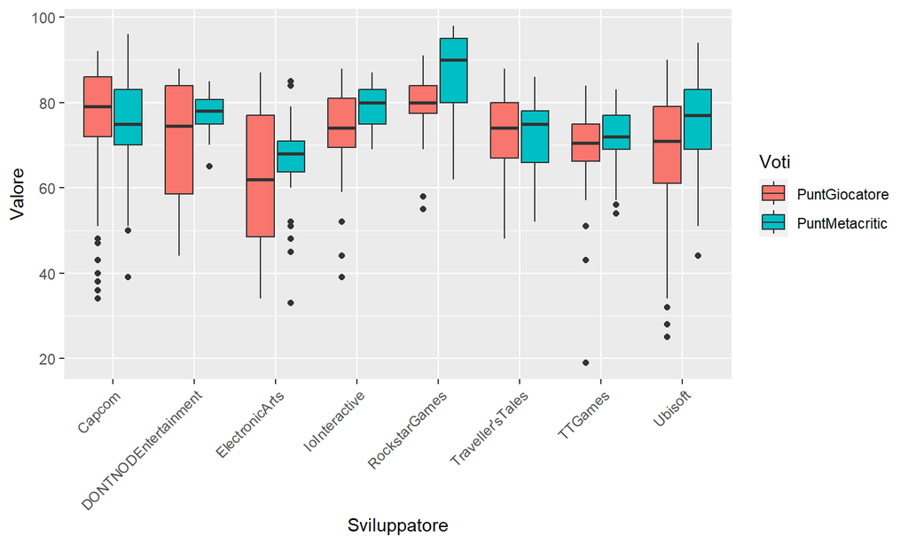

Interessanti l’analisi dei casi DONTNODE - ElectronicArts e RockstarGames

## Analisi sull’andamento di pubblicazione

## Action

Ci sono stati dei cambiamenti nella produzione di giochi? In blu ho la quantità di giochi, in rosso il voto della critica e in verde i voti dei giocatori.

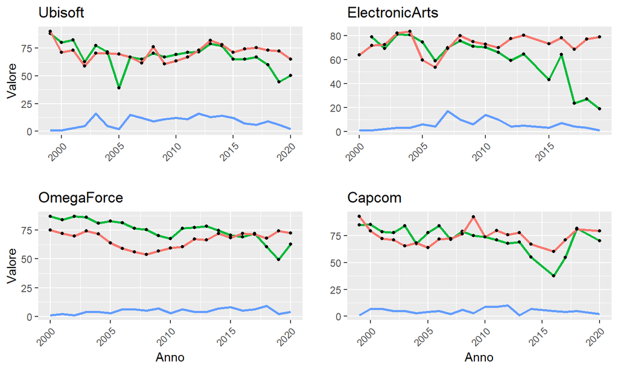

## Action-RPG

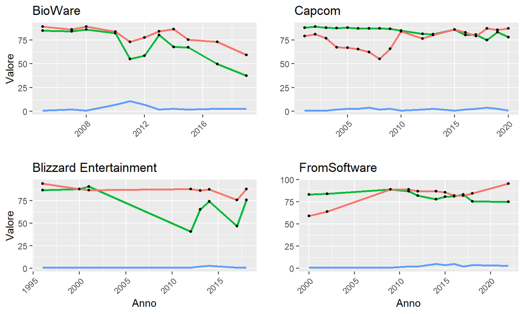

## Action-Adventure

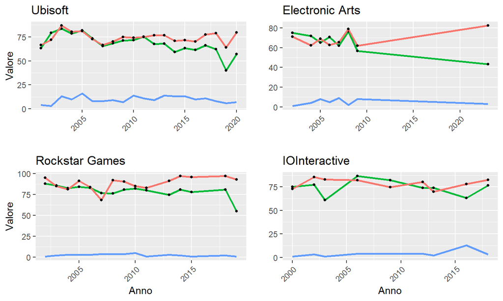

## Analisi delle piattaforme

## Genere Action

Quale è la piattaforma su cui si gioca di più?

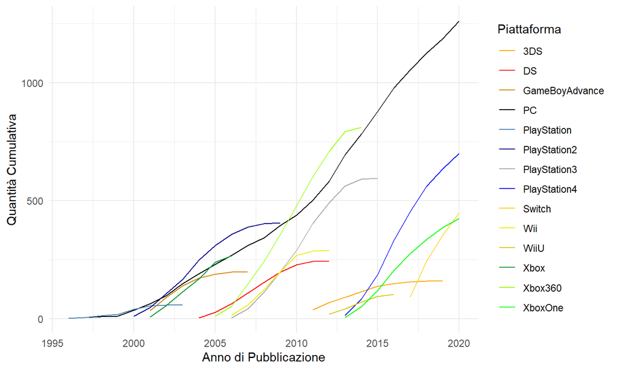

## Action RPG

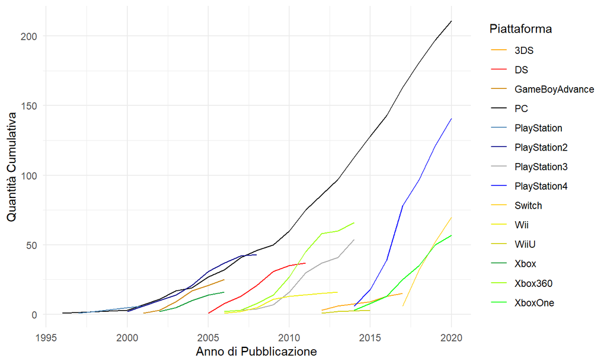

La PlayStation3 segue la Xbox360 da vicino, ma col cambio di generazione a PlayStation4 - XboxOne la Microsoft non regge il confronto.

## Action Adventure

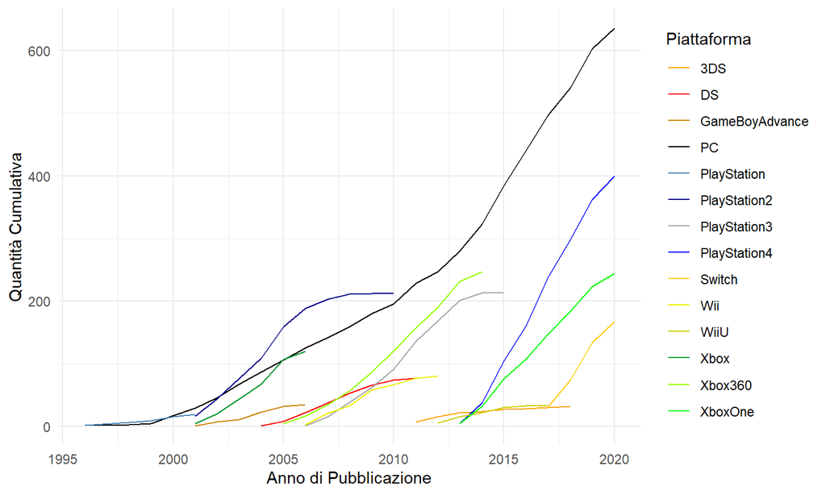

## Conclusioni

- La Ubisoft domina la produzione in 2 generi su 3, EA e Capcom comunque presenti in più generi. Il genere Action-RPG ha un numero di titoli inferiore agli altri due generi.
- Si nota come generalmente la critica sia più propensa a valutazioni più alte rispetto a quelle dei giocatori; questo però non sempre vale e come nel caso della Capcom per il genere Action-RPG.
- Si può notare come il proseguimento con nuovi titoli di serie storiche di successo non sempre significa che i nuovi titoli siano apprezzati. Stessa storia vale per la maggior parte dei DLC rilasciati.
- L’interesse per i generi Action è aumentato nel tempo come in generale l’interesse per il mondo videoludico. Si osserva anche l’ormai storica rivalità tra Microsoft e Sony che col passare del tempo sta volgendo a favore di quest’ultima. Interessante è anche il fatto che col passare del tempo si è cercato di aumentare il numero di giochi piattaforma.